# Analiza svjetlosnog onečišćenja sjeverne Hrvatske

## Luka Štefanić, Varaždin, 2026.

# Sadržaj

1. Sažetak
2. Uvod
3. Ciljevi
4. Podaci
5. Dohvat podataka
6. Distribucija podataka
7. Trend kretanja podataka
8. Geoprostorna godišnja analiza
9. Mjesečna analiza

   9.1. Varaždin  
   9.2. Čakovec  
   9.3. Koprivnica  
   9.4. Krapina
10. Demografska analiza regije
11. Meteorološka analiza regije
12. Analiza korelacije
13. Zaključak

## Sažetak

Ovaj projekt istražuje dinamiku svjetlosnog onečišćenja na području sjeverne Hrvatske koristeći satelitske podatke projekta NASA Black Marble. Rad obuhvaća vremensku analizu promjena intenziteta svjetlosti te detaljan prostorni prikaz stanja na razini regije i pojedinih urbanih središta sjeverne Hrvatske.

## Uvod

Svjetlosno onečišćenje postaje jedan od najbrže rastućih ekoloških problema modernog doba, utječući na zdravlje ljudi, bioraznolikost, energetsku učinkovitost, ali i na astronomska opažanja. Fenomen svjetlosnog onečišćenja opisuje se kao promjene razine osvijetljenosti koja se emitira putem umjetnih izvora svjetlosti. Prema istraživanjima, noćno nebo svake godine postaje prosječno 10% sjajnije u odnosu na prethodnu godinu [1] . Tijekom narednih 20tak godina, očekuje se da će noćno nebo biti svjetlije četiri puta [1].

Sjeverna Hrvatska predstavlja specifičan poligon za proučavanje ovog fenomena. Zahvaljujući naprednim senzorima poput VIIRS-a, danas se može precizno mjeriti umjetno zračenje iz svemira. Ovaj rad koristi te podatke kako bi kvantificirao promjene u osvjetljenju koje su se dogodile u posljednjih nekoliko godina uslijed urbanizacije i modernizacije infrastrukture.

[1] James Ashworth, *Increasing light pollution is drowning out the stars*, 19.01.2023., izvor: https://www.nhm.ac.uk/discover/news/2023/january/increasing-light-pollution-drowning-out-stars.html

## Ciljevi

1. Analiza vremenskih trendova: utvrditi kretanje intenziteta svjetlosnog onečišćenja u sjevernoj Hrvatskoj kroz višegodišnje razdoblje
2. Regionalna usporedba: prikazati razlike u razinama onečišćenja između različitih regija (npr. Međimurje, Zagorje, Podravina).
3. Urbana mikro-analiza: provesti usporedbu specifičnih gradova kako bi se odredilo koji centri imaju najveći doprinos ukupnom svjetlosnom onečišćenju na području sjeverne Hrvatske

## Podaci

NASA Black Marble je skupina znanstvenih podataka koji prikazuju Zemlju noću u visokoj rezoluciji (500m) [2], koristeći VIIRS instrument na satelitima Suomi NPP, NOAA-20 i NOAA-21 za praćenje ljudskih aktivnosti i prirodnih promjena od 2012. godine. [2] Podaci su atmosferski ispravljeni, uklonjene su smetnje poput mjesečine i refleksije svjetlosti, omogućujući analizu urbanizacije, infrastrukture, prirodnih katastrofa i svjetlosnog onečišćenja. [2]

Slijedeća slika prikazuje proces kalibracije podataka za NASA-in projekt "Black Marble", odnosno kako se od sirovog satelitskog signala dolazi do čiste slike noćnih svjetala Zemlje.

- Satelitski senzor (VIIRS): prima ukupno zračenje s površine, ali i "šum" iz drugih izvora.
- Izvori smetnji: senzor mora prepoznati i ukloniti utjecaj mjesečine, svjetlucanja atmosfere i raspršene sunčeve svjetlosti
- Atmosferska korekcija: uklanjaju se efekti oblaka, vlage i čestica u zraku kako bi se vidjela stvarna površina
- BRDF korekcija: ispravljaju se razlike u refleksiji ovisno o kutu gledanja, godišnjem dobu ili prisutnosti snijega
- Konačni rezultat: nakon svih ovih filtera dobivaju se precizni podaci o ljudskoj aktivnosti i umjetnoj rasvjeti na tlu

[figure not shown]

Slika 1: Shematski prikaz obrade NASA Black Marble podataka (izvor: [2])

[2] NASA's Black Marble, *Advancing the Science of Earth at Night*, izvor: https://blackmarble.gsfc.nasa.gov/

## Dohvat podataka

Za dohvat podataka putem BlackMarble sučelja potrebno je definirati geografski okvir koji određuje područje interesa promatranja. U tu svrhu koristi se datoteka koja sadrži prostorni opis sjeverne Hrvatske u obliku geografskih poligona. Navedeni poligon prema koje se dohvaćaju podaci vidljiv je na slici ispod.

[figure not shown]

Podaci se s BlackMarble sučelja dohvaćaju standardiziranim API metodama. Sučelje na temelju proslijeđenog geografskog poligona automatski generira i vraća rasterske zapise koji sadrže tražene informacije za odabrano područje.

Jednom dohvaćeni podaci pohranjuju se u trajnu memoriju, čime se omogućuje njihovo ponovno korištenje bez potrebe za ponovnim pristupom BlackMarble sučelju.

Podaci sadrže sljedeće varijable:

- **time** – vremenska komponenta podataka, izražena u godinama ili mjesecima
- **y** – prostorna varijabla koja predstavlja geografsku širinu (latitudu) piksela
- **x** – prostorna varijabla koja predstavlja geografsku dužinu (longitudu) piksela
- **NearNadir_Composite_Snow_Free** – vrijednost radijance izražena u nW/cm²sr

Radijanca je korigirana spektralna gustoća toka zračenja koju detektira VIIRS Day/Night Band (DNB) senzor, izražena u nanovatima po centimetru kvadratnom po steradijanu (n*W / cm²* sr) [3]. Laički rečeno, to je mjera intenziteta svjetlosti kojom neko mjesto na Zemlji "svijetli" prema svemiru, nakon što se iz snimke uklone sve prirodne smetnje poput mjesečine ili magle. Na prikazu ispod vidljivo je prvih i zadnjih pet redova podataka iz promatranog skupa te ukupan broj zapisa (856960 redova), kao i broj atributa (stupaca).

[3] Zhuosen Wang et al, *Black Marble User Guide (Collection 2.0)*, listopad 2024., izvor: https://landweb.modaps.eosdis.nasa.gov/data/userguide/BlackMarbleUserGuide_Collection2.0_20241203.pdf

|  | time | y | x | NearNadir_Composite_Snow_Free |
| --- | --- | --- | --- | --- |
| 0 | 2012-01-01 | 46.548039 | 15.593872 | NaN |
| 1 | 2012-01-01 | 46.548039 | 15.598039 | NaN |
| 2 | 2012-01-01 | 46.548039 | 15.602205 | NaN |
| 3 | 2012-01-01 | 46.548039 | 15.606372 | NaN |
| 4 | 2012-01-01 | 46.548039 | 15.610539 | NaN |
| ... | ... | ... | ... | ... |
| 856955 | 2024-01-01 | 45.885539 | 17.289705 | NaN |
| 856956 | 2024-01-01 | 45.885539 | 17.293872 | NaN |
| 856957 | 2024-01-01 | 45.885539 | 17.298039 | NaN |
| 856958 | 2024-01-01 | 45.885539 | 17.302205 | NaN |
| 856959 | 2024-01-01 | 45.885539 | 17.306372 | NaN |

856960 rows × 4 columns

## Distribucija podataka

Distribucija podataka pokazuje kako su vrijednosti raspoređene unutar skupa. Ova analiza pomaže razumjeti **raspon, koncentraciju i rijetke ekstremne vrijednosti** u skupu podataka prije daljnjih statističkih metoda i vizualizacija.

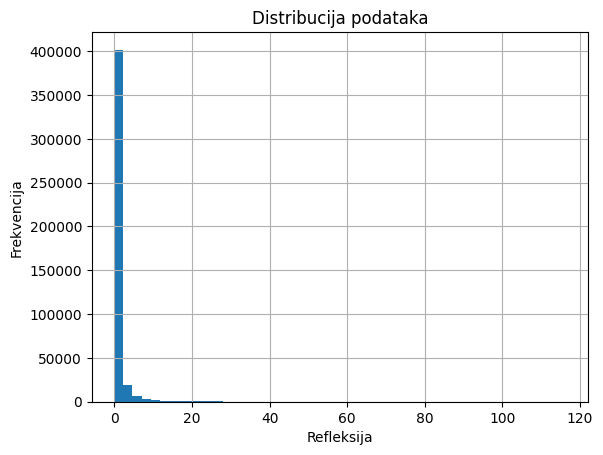

Distribucija originalnog skupa podataka pokazuje da veliki broj piksela ima vrijednost 0, što ukazuje na nedostatak mjerenja ili nisku radijancu u tim područjima. Ovaj obrazac je tipičan za noćne satelite, gdje tamna ili nenastanjena područja daju nultu vrijednost, dok manji broj piksela ima nenulte ili visoke radijance.

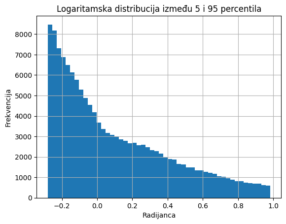

Kako bi se uklonili nedostajući podaci (NaN) i ekstremi, iz razmatranja su izuzeti donji i gornji repovi distribucije te su zadržane vrijednosti između 5. i 95. percentila. Time se dobiva jasnija slika o distribuciji: ona je desno asimetrična, što potvrđuje da većina područja ima nisku razinu svjetla, dok mali broj urbanih zona uzrokuje duži desni rep distribucije.

Bitno je za napomenuti da je u ovom procesu korištena logaritamska transformacija. Logaritamska transformacija koristi se za smanjenje dinamičkog raspona podataka, čime se postiže bolja vizualna razlučivost između vrlo niskih i vrlo visokih vrijednosti radijance. Time se sprječava da mali broj ekstremno svijetlih točaka (poput centara gradova) vizualno potisne većinu podataka koji se nalaze u nižim vrijednostima.

## Trend kretanja podataka

Analiza trendova pokazuje kako se vrijednosti podataka mijenjaju kroz vrijeme, što omogućuje uvid u promjene razine svjetlosnog onečišćenja tijekom promatranog perioda.

Prosječna radijanca kroz vrijeme pokazuje **opći porast**, što ukazuje na povećanje svjetlosnog onečišćenja u sjevernoj Hrvatskoj, uz povremene manje padove u nekim periodima.

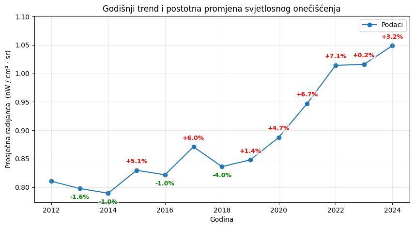

Vidljivo je da su najznačajniji trendovi rasta radijance zabilježeni u periodu od 2019. do 2022. godine. Iako bi se tijekom 2020. godine, uslijed smanjenog ljudskog kretanja i aktivnosti zbog pandemije COVID-19 očekivao pad svjetlosnog onečišćenja, prosječne vrijednosti ipak pokazuju blagi rast, što može biti posljedica intenziviranja urbanih aktivnosti i trajnog povećanja svjetlosnog opterećenja u gradskim područjima.

## Geoprostorna godišnja analiza

Kako bi se prikazao razmjer rasta svjetlosnog onečišćenja na području sjeverne Hrvatske, izrađena je animacija promjene radijance u razdoblju od 2012. do 2024. godine. Vizualizacija jasno ističe žarišne točke, pri čemu crvena boja označava maksimalne, a svijetložuta minimalne razine onečišćenja. Godina je istaknuta u gornjem lijevom kutu, dok legenda na dnu prati dinamički raspon izmjerenih vrijednosti za svaku godinu. Na promatranoj animaciji vidljiv je generalni trend povećanja svjetlosnog onečišćenja iz godine u godinu.

[figure not shown]

## Mjesečna analiza

Nakon godišnjeg prikaza, slijede mjesečne analize. Analizirat će se mjesečni podaci od siječnja 2023. do prosinca 2025. godine. Kao i kod godišnje analize, podatkovni skup sadrži atribute o vremenu, koordinate te izmjerenu vrijednost radijance.

|  | time | y | x | NearNadir_Composite_Snow_Free |
| --- | --- | --- | --- | --- |
| 0 | 2023-01-01 | 46.548039 | 15.593872 | NaN |
| 1 | 2023-01-01 | 46.548039 | 15.598039 | NaN |
| 2 | 2023-01-01 | 46.548039 | 15.602205 | NaN |
| 3 | 2023-01-01 | 46.548039 | 15.606372 | NaN |
| 4 | 2023-01-01 | 46.548039 | 15.610539 | NaN |

Mjesečnim trendom može se utvrditi koji su mjeseci najkritičniji po pitanju svjetlosnog onečišćenja. Podaci se grupiraju te se radi prosjek po mjesecu za cijelo područje sjeverne Hrvatske. Iz prikaza je vidljivo da linija dosta varira, s minimumom u srpnju 2024. godine (ispod **0.8 nW / cm² ⋅ sr**) te maksimumom u lipnju 2025. godine (oko **1.7 nW / cm² ⋅ sr**). Također je vidljivo na grafu sezonalnosti da je radijanca nešto viša u zimskim mjesecima te da se smanjuje u proljetnim i ljetnim mjesecima, uz iznimku lipnja koji prikazuje odstupanja od navedenog.

Kako bi se utvrdilo koji gradovi sjeverne Hrvatske najviše doprinose onečišćenju, u nastavku će se napraviti analiza za svako od administrativnih sjedišta četiriju sjevernih hrvatskih županija.

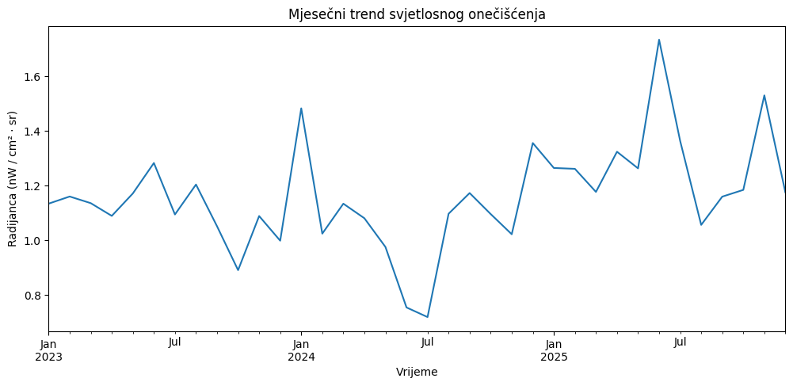

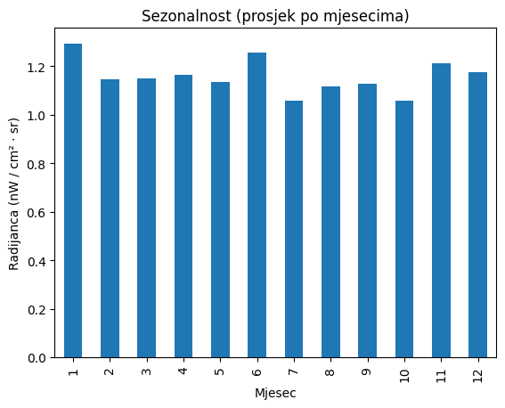

**Napomena!** Na grafovima koji slijede, puna linija označava srednju vrijednost (prosjek) mjerenja radijance u promatranom razdoblju. Osjenčano područje oko linije predstavlja 95-postotni interval pouzdanosti, koji vizualizira razinu varijabilnosti podataka. Širina tog područja ukazuje na raspršenost mjerenja: šire osjenčanje sugerira veća odstupanja pojedinačnih očitanja od prosjeka, dok uže područje potvrđuje veću ujednačenost i stabilnost podataka

### Varaždin

Dodatne analize započet će se gradom Varaždinom. Varaždin je najveći grad u promatranom skupu, stoga je za očekivati da će ovdje vrijednosti svjetlosnog onečišćenja, tj. radijance biti najveće. Vrijednosti se grupiraju po mjesecu za svaku od promatranih godina te se izračunava prosjek.

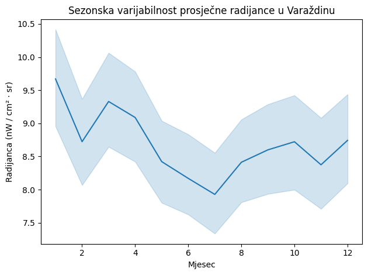

Analiza radijance za Varaždin pokazuje sezonsku varijabilnost s vršnim vrijednostima u siječnju i ožujku te najnižim intenzitetom u srpnju. Dodatno su uočene fluktuacije s privremenim padovima u veljači i studenom, nakon kojih slijedi ponovni rast izmjerene svjetlosti.

Rezultati potvrđuju tvrdnju o povećanom intenzitetu radijance tijekom zimskih mjeseci, što korelira s duljim radom umjetne rasvjete zbog dužih noći i manjkom vegetacijskog pokrova koji bi blokirao izravnu emisiju svjetlosti prema satelitu. Suprotno tome, ljetni minimum ukazuje na utjecaj kraćih noći i prisutnosti vegetacije na smanjenje izmjerenih vrijednosti.

Kako bi se dobila još bolja slika, napravit će se grupiranje po vremenskom periodu te izračunati prosjek za promatrani period.

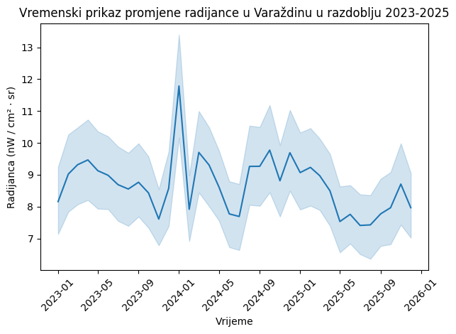

Graf potvrđuje ponavljajući ciklus vidljiv na prethodnom prikazu, gdje svaka godina ima brijeg tijekom zimskih mjeseci i dolinu tijekom ljetnih. Siječanj 2024. godine predstavlja neuobičajeno visok ekstrem koji može ukazivati na specifične atmosferske uvjete ili pojačanu rasvjetu te godine.

U nastavku slijedi vizualizacija gdje se za svaku promatranu godinu i mjesec prikazuje svjetlosno onečišćenje u administrativnim granicama grada Varaždina. Pri dnu prikaza nalazi se legenda koja prikazuje raspon boja te vrijednosti koje one označavaju minimalnu radijancu s lijeve te maksimalnu s desne strane.

[figure not shown]

## Čakovec

Nakon Varaždina, slijedi analiza administrativnog sjedišta Međimurske županije, Čakovec. Graf ispod pokazuje sezonsku varijabilnost prosječne radijance, gdje je opet vidljivo da je radijanca nešto viša u zimskim mjesecima. Značajno odstupanje vidljivo je u prosincu, što može ukazivati na povećanu rasvjetu uslijed prosinačkih blagdana.

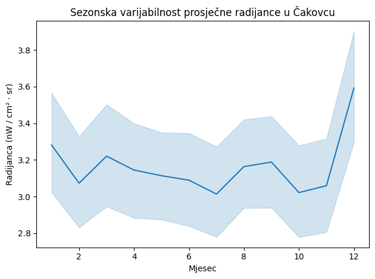

Vremenski prikaz promjene radijance kroz razdoblje prikazuje kontinuirani trend rasta srednje radijance u Čakovcu, uz primjetan skok intenziteta krajem 2024. godine. Jasno su vidljive sezonske oscilacije s vrhuncima u zimskim mjesecima te padovima tijekom proljeća i jeseni. Povećanje širine osjenčanog područja sugerira sve veću varijabilnost podataka kroz vrijeme, što može ukazivati na promjene u dinamici urbane rasvjete ili atmosferskih utjecaja.

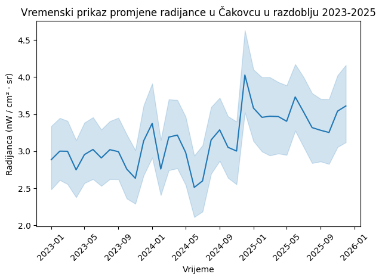

U nastavku slijedi vizualizacija gdje se za svaku promatranu godinu i mjesec prikazuje svjetlosno onečišćenje u administrativnim granicama grada Čakovca. Pri dnu prikaza nalazi se legenda koja prikazuje raspon boja te vrijednosti koje one označavaju minimalnu radijancu s lijeve te maksimalnu s desne strane.

[figure not shown]

## Koprivnica

Slijedi analiza najistočnijeg administrativnog sjedišta u promatranom skupu, grada Koprivnice. Sezonska varijabilnost u Koprivnici pokazuje stabilno visoke vrijednosti radijance u prvoj polovici godine, uz primjetan pad prema listopadu, koji je ujedno i najtamniji mjesec. Široko osjenčano područje kroz cijelu godinu ukazuje na konstantno visoku varijabilnost u razinama svjetlosnog onečišćenja neovisno o sezoni.

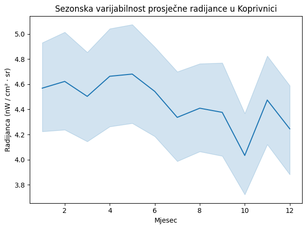

U razdoblju od 2023. do 2025. godine u Koprivnici je vidljiv trend smanjenja ukupne radijance. Najveće vrijednosti zabilježene su početkom 2023. godine, nakon čega slijedi pad i stabilizacija na nižim razinama s karakterističnim sezonskim oscilacijama. Smanjenje širine osjenčanog područja prema 2025. godini ukazuje na manju varijabilnost podataka i potencijalno ujednačenije upravljanje javnom rasvjetom.

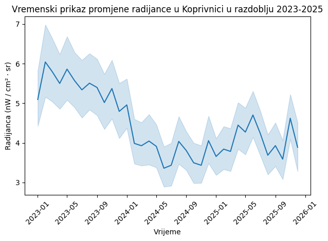

U nastavku slijedi vizualizacija gdje se za svaku promatranu godinu i mjesec prikazuje svjetlosno onečišćenje u administrativnim granicama grada Koprivnice. Pri dnu prikaza nalazi se legenda koja prikazuje raspon boja te vrijednosti koje one označavaju minimalnu radijancu s lijeve te maksimalnu s desne strane.

[figure not shown]

## Krapina

Posljednji promatrani grad u ovom skupu jest Krapina. Sezonska varijabilnost u Krapini pokazuje silazan trend radijance prema kraju godine, uz najniže vrijednosti u listopadu. Zanimljiv je značajan pad u srpnju nakon kojeg slijedi nagli kolovozni vrhunac, što se može povezati s intenzivnim ljetnim manifestacijama.

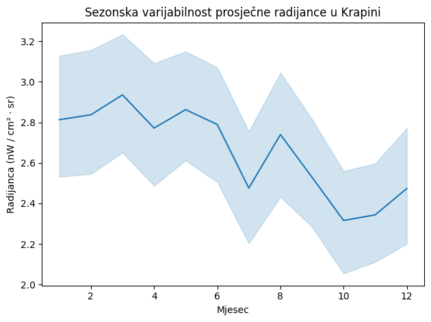

Vremenski prikaz za Krapinu pokazuje izrazito nestabilan trend s velikim amplitudama u radijanci. Iako su prisutni periodični vrhunci (poput onog početkom 2024.), opći trend naginje blagom padu ili stagnaciji, uz vidljivo smanjenje intenziteta u drugoj polovici 2024. godine. Velika osjenčana područja ukazuju na visoku varijabilnost podataka, što je u Krapini često povezano s konfiguracijom terena koja može pojačati utjecaj magle i vlage na refleksiju svjetla prema satelitu.

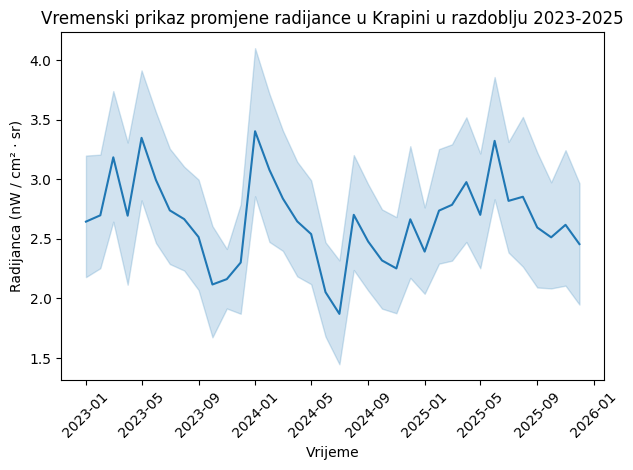

U nastavku slijedi vizualizacija gdje se za svaku promatranu godinu i mjesec prikazuje svjetlosno onečišćenje u administrativnim granicama grada Krapine. Pri dnu prikaza nalazi se legenda koja prikazuje raspon boja te vrijednosti koje one označavaju minimalnu radijancu s lijeve te maksimalnu s desne strane.

[figure not shown]

## Demografska analiza regije

U ovoj sekciji provest će se demografska analiza sjeverne Hrvatske. Cilj analize je dobiti sveobuhvatnu sliku o demografskom stanju regije te na taj način istražiti korelaciju između svjetlosnog onečišćenja i naseljenosti. Demografski podaci korišteni u ovoj analizi preuzeti su iz baze podataka Global Human Settlement Layer (GHSL). GHSL pruža globalno usporedive prostorne podatke o gustoći stanovništva, izgrađenim površinama i obrascima naseljenosti, kombinirajući satelitske snimke visoke rezolucije, podatke popisa stanovništva i druge geografske izvore. Podaci su otvorenog tipa te su dostupni u obliku rastera, što omogućuje detaljnu analizu prostorne raspodjele stanovništva i njihovu usporedbu s prostornim obrascima svjetlosnog onečišćenja.

Važno je za napomenuti da se podaci gledaju po epohama od 5 godina, što znači da su najnoviji podaci dostupni za 2025. godinu, a postoje projekcije i za 2030. U ovom istraživanju gledaju se podaci za 2025. godinu. Preuzeta datoteka obuhvaća prostor od nekoliko zemalja Europe pri čemu se dobiva slijedeći prikaz na geografskoj karti.

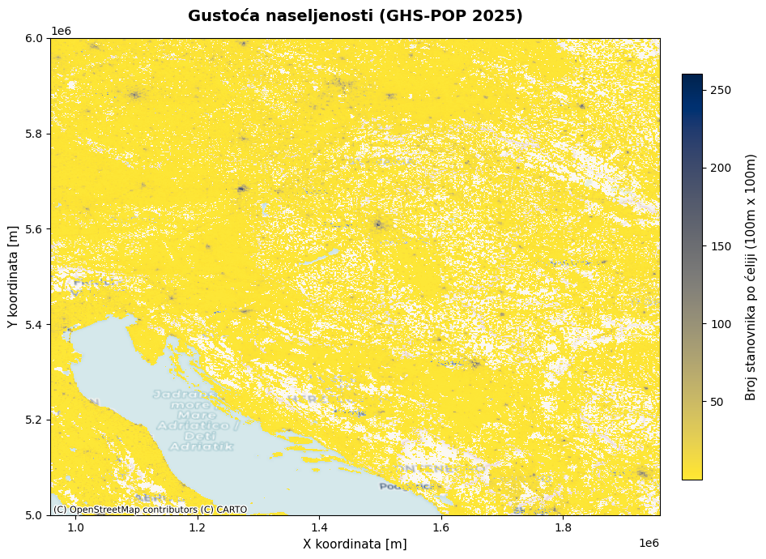

Kako se u ovom projektu analizira sjeverna Hrvatska, fokusirat će se na navedeno područje. Uključene su i granice okruga za jednostavnije opažanje naseljenosti određenih dijelova.

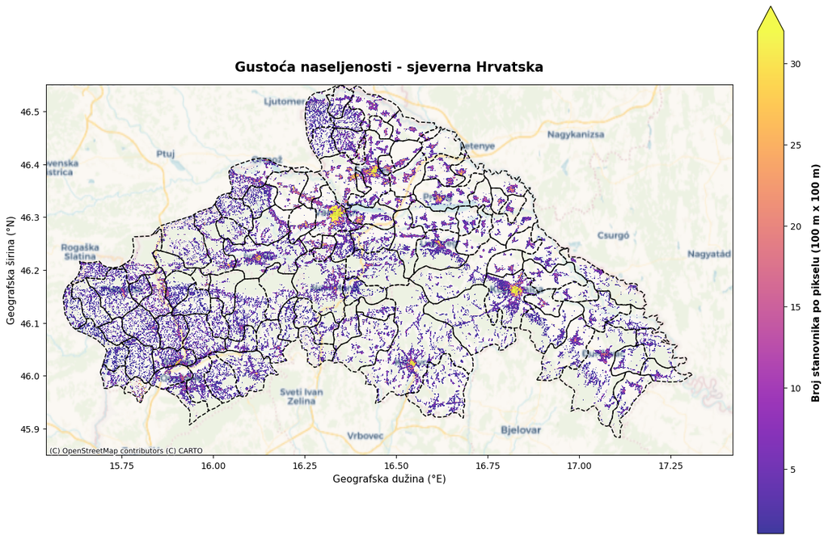

Na idućem primjeru, moguće je vidjeti naseljenost grada Varaždina. Karta prikazuje raspodjelu gustoće naseljenosti gdje svjetložute nijanse označavaju najveću koncentraciju stanovnika po pikselu. Iz prikaza je vidljivo da je najgušće naseljeno samo središta Varaždina, dok se prema periferiji i okolnim naseljima postupno smanjuje.

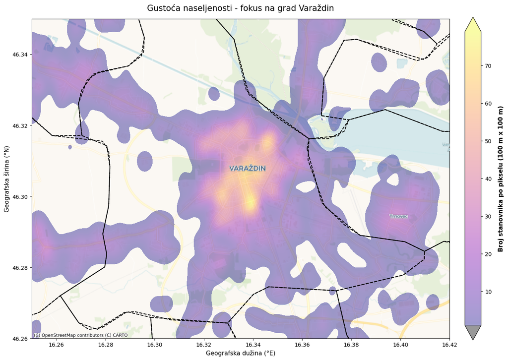

## Meteorološka analiza regije

Osim demografske, napravit će se i meteorološka analiza regije. Cilj je proučiti kako određene meteorološke varijable poput padalina, temperature ili naoblake utječu na svjetlosno onečišćenje. Kao referentna točka promatrat će se 2025. godina, i to za svaki mjesec.

U svrhu istraživanja korišteni su podaci iz europskog sustava Copernicus Climate Data Store, točnije kroz globalni model ERA5-Land. ERA5-Land skup je podataka koji pruža mjesečne prosjeke meteoroloških i hidroloških varijabli nad kopnenim područjima. Podaci su dostupni od 1950. godine do danas i temelje se na kombinaciji mjerenja i numeričkog modeliranja. Skup uključuje varijable poput temperature zraka, oborina, vlage tla, snježnog pokrivača i vjetra. Prostorna rezolucija iznosi približno 9 km, što omogućuje detaljne analize klimatskih i okolišnih uvjeta. U nastavku slijedi kartografski prikaz odabranih varijabli za bolje shvaćanje podataka u preuzetom skupu.

[figure not shown]

Priloženi grafički prikaz prikazuje prostorno-vremensku distribuciju prosječne mjesečne temperature zraka u sjevernoj Hrvatskoj kroz 12 mjeseci. Karte jasno vizualiziraju sezonski hod temperatura, pri čemu zimski mjeseci (prosinac, siječanj, veljača) bilježe najniže vrijednosti s padom i ispod 0 °C, dok ljetno razdoblje (lipanj, srpanj, kolovoz) donosi maksimume koji prelaze 20 °C. Zajednička skala s desne strane omogućuje izravnu i preciznu usporedbu intenziteta toplinske dinamike među svim mjesecima.

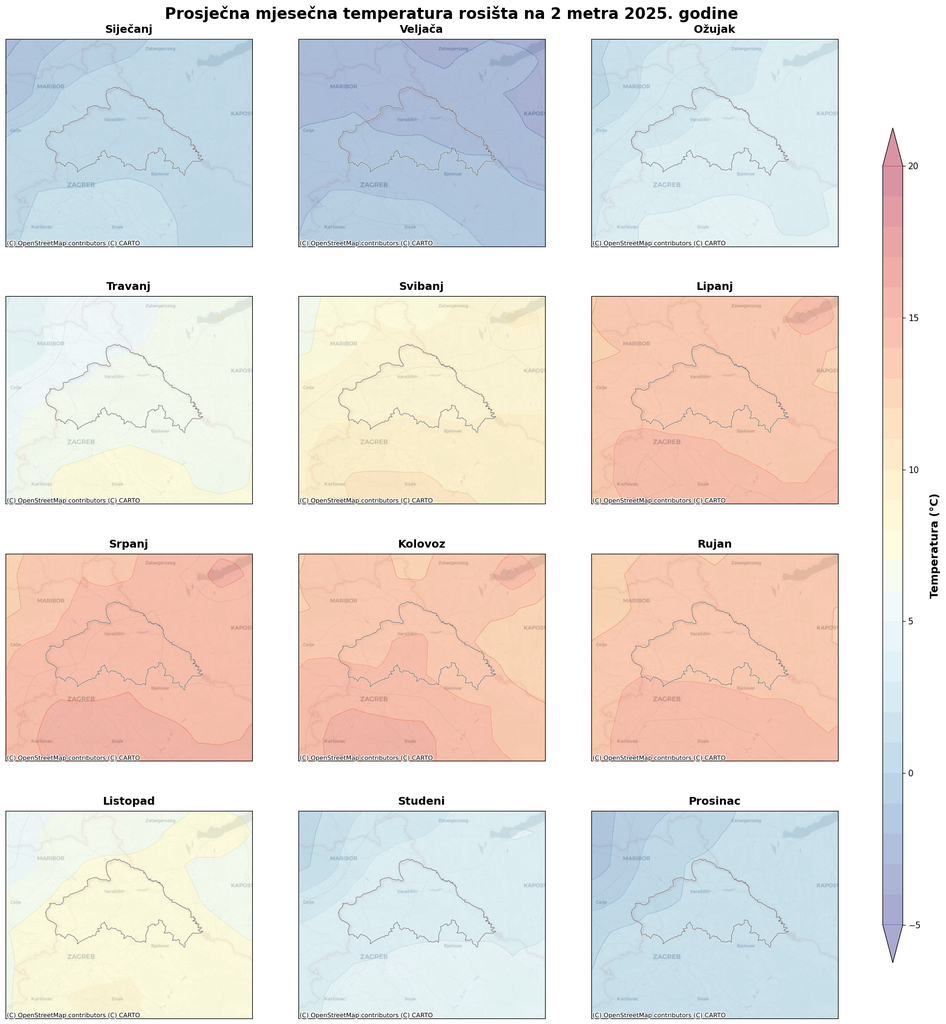

Priloženi grafički prikaz vizualizira prostorno-vremensku distribuciju prosječne mjesečne temperature rosišta na visini od 2 metra u sjevernoj Hrvatskoj. Karte jasno prate sezonski hod apsolutne vlage u zraku, pri čemu zimski mjeseci bilježe najniže vrijednosti (ispod 0 °C) što indicira suh zrak, dok ljetno razdoblje donosi maksimume iznad 15 °C zbog intenzivnijeg isparavanja i veće količine vlage. Iscrtane konture predstavljaju linije istih vrijednosti rosišta koje zorno prikazuju mikroklimatske razlike unutar regije. Zajednička skala s desne strane omogućuje izravnu usporedbu i precizno praćenje godišnje dinamike zasićenosti zraka vlagom.

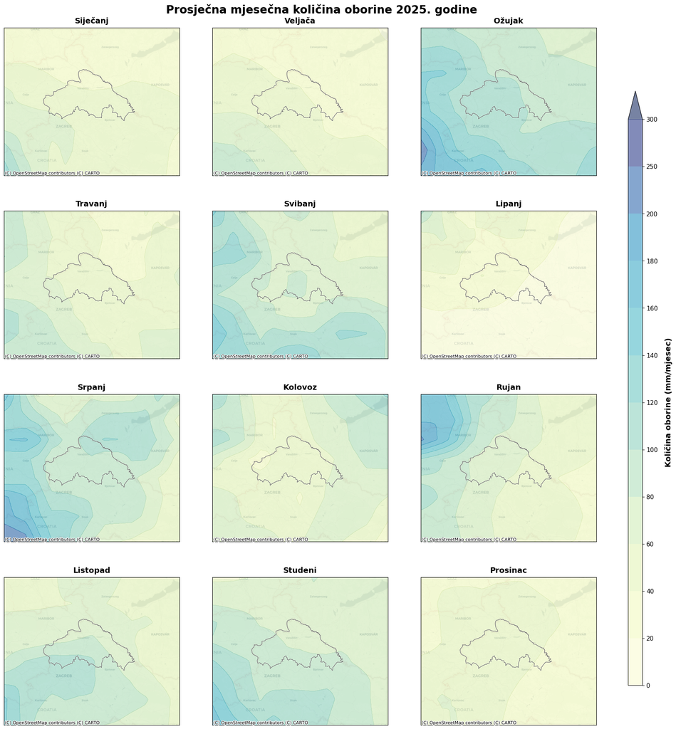

Priloženi grafički prikaz prikazuje prostorno-vremensku distribuciju prosječne mjesečne količine oborina u sjevernoj Hrvatskoj izraženu u milimetrima po mjesecu (mm/mjesec). Karte zorno vizualiziraju izraženu sezonsku i prostornu dinamiku, gdje zapadni i jugozapadni dijelovi regije dosljedno bilježe veće količine oborina u odnosu na istočne, nizinske krajeve. Iscrtane konture predstavljaju izohijete – linije koje spajaju mjesta s istom količinom oborina. Zajednička skala s desne strane omogućuje izravnu usporedbu intenziteta oborinskih režima, ističući kasno proljetne i jesenske maksimume te općenito suša razdoblje u hladnijem dijelu godine.

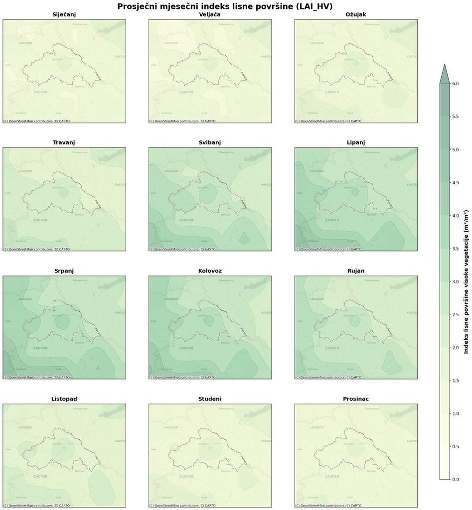

## Analiza korelacije

Nakon inicijalne obrade i analize pojedinačnih skupova podataka — koji obuhvaćaju satelitska očitavanja svjetlosnog onečišćenja, demografske pokazatelje te meteorološke parametre — slijedi istraživanje njihove međusobne povezanosti. U nastavku je prikazana Pearsonova korelacijska matrica koja matematički definira te odnose, nakon čega slijedi detaljan sažetak i interpretacija ključnih rezultata. Vrijedi napomenuti da se koeficijenti u matrici kreću u rasponu od -1 do 1. Vrijednost 1 predstavlja savršenu pozitivnu korelaciju, dok vrijednost -1 označava savršenu negativnu korelaciju (obrnuto proporcionalan odnos). Vrijednost 0 ukazuje na potpuni izostanak linearne povezanosti između promatranih varijabli.

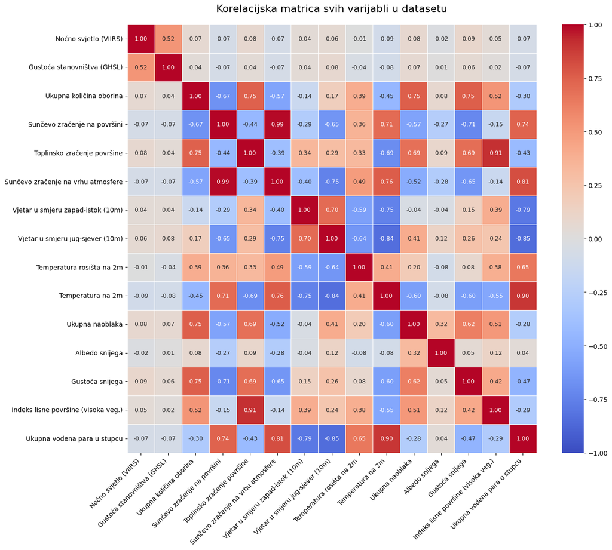

#### 1. Antropogeni utjecaj (GHSL i VIIRS)

- **Gustoća stanovništva vs. noćno svjetlo [0.52]:** Bilježi se **umjereno jaka pozitivna korelacija**. Emisija svjetla izravno je vezana uz ljudsku prisutnost. Koeficijent sugerira da intenzitet svjetla ne raste potpuno linearno s populacijom, što je razumno pošto na njega utječu i drugi faktori poput industrijskih ili prometnih zona.
- **Odsutnost veze s klimom:** Korelacije noćnog svjetla (VIIRS) i gustoće naseljenosti (GHSL) sa svim klimatskim varijablama blizu su nule (-0.09 do 0.09). Vremenski uvjeti nemaju linearan utjecaj na dugoročni raspored naselja i emisiju rasvjete. Ovaj pokazatelj u potpunosti je u skladu s tehničkim specifikacijama VIIRS skupa podataka, budući da sirovi satelitski snimci prije finalizacije i objave prolaze kroz procese filtriranja atmosferskih utjecaja, uklanjanja naoblake i korekcije refleksije svjetlosti od podloge.

#### 2. Jake pozitivne meteorološke korelacije

- **Sunčevo zračenje na površini vs. na vrhu atmosfere [0.99]:** Gotovo savršena korelacija. Količina energije na tlu izravno je diktirana dolaznom energijom na vrhu atmosfere.
- **Toplinsko zračenje površine vs. indeks lisne površine [0.91]:** Izrazito jaka korelacija. Jedan od mogućih uzroka jest što je vegetacija gušća, gornji sloj lišća u krošnjama upija više sunčeve energije i jače se zagrijava. Zbog toga to bujno lišće snažno isijava toplinu prema gore, što sateliti bilježe kao povećano toplinsko zračenje površine.
- **Temperatura na 2m vs. ukupna vodena para [0.90]:** Jaka veza koja odražava pravilo da topliji zrak zadržava znatno više vlage u atmosferi.
- **Temperatura na 2m vs. sunčevo zračenje [0.71 i 0.76]:** Očekivana povezanost gdje veći intenzitet zračenja izravno podiže temperaturu zraka.

#### 3. Jake negativne meteorološke korelacije

- **Temperatura na 2m vs. komponente vjetra [-0.75 i -0.84]:** Niže temperature usko su povezane s jačim vjetrovima, što ukazuje na zimske prodore hladnog zraka i nestabilnosti.
- **Ukupna količina oborina vs. sunčevo zračenje na površini [-0.67]:** Logična negativna veza jer pojava oborina zahtijeva oblake koji mehanički blokiraju sunčevu svjetlost.

#### 4. Dinamika naoblake, vlage i oborina

- **Ukupna naoblaka vs. oborine [0.75] i gustoća snijega [0.62]:** Očekivano visoka i stabilna pozitivna korelacija.
- **Ukupna naoblaka vs. toplinsko zračenje površine [0.69]:** Veća količina oblaka zadržava toplinu pri tlu, što pojačava toplinsku emisiju površine.
- **Temperatura na 2m vs. ukupna naoblaka [-0.60]:** Gusti oblaci blokiraju dnevno zagrijavanje, što rezultira nižim temperaturama zraka.

#### 5. Utjecaj biosfere i vegetacije na mikroklimu

- **Indeks lisne površine vs. toplinsko zračenje površine [0.91]:** Izrazito visoka korelacija odražava sinkroni sezonski hod. U ljetnim mjesecima, kada vegetacija doseže svoj maksimum, atmosfera je najtoplija i najvlažnija, zbog čega je i atmosfersko toplinsko zračenje prema površini na svom godišnjem vrhuncu.
- **Indeks lisne površine vs. temperatura na 2m [-0.55]:** Umjereno jaka negativna korelacija detektira efekt hlađenja. Gusta vegetacija stvara sjene te aktivno snižava temperaturu prizemnog sloja.
- **Indeks lisne površine vs. količina oborina [0.52] i naoblaka [0.51]:** Pozitivna korelacija između indeksa lisne površine, oborina i naoblake rezultat je sezonskog hoda klimatskih faktora. Porast temperature i dostupnost vode u tlu u proljetnom razdoblju potiču intenzivan razvoj lisne mase. Istovremeno, ljetne mjesece karakterizira česta pojava naoblake i lokalnih pljuskova, što objašnjava dobivene vrijednosti korelacije.

#### 6. Dinamika snježnog pokrivača i oborina

- **Gustoća snijega vs. ukupna količina oborina [0.75] i naoblaka [0.62]:** Jaka pozitivna korelacija potvrđuje sinoptičke procese u hladnom dijelu godine, gdje sustavi s gustom naoblakom izravno utječu na akumulaciju snježnog pokrivača.
- **Gustoća snijega vs. sunčevo zračenje [-0.71 na površini, -0.65 na vrhu atmosfere]:** Visoka negativna korelacija. Prisutnost i zadržavanje snijega vezani su uz zimska razdoblja s najnižim kutom upada sunčevih zraka i minimalnom insolacijom.
- **Gustoća snijega vs. temperatura na 2m [-0.60]:** Stabilna negativna korelacija koja odražava osnovno fizikalno pravilo – veće količine i veća gustoća snijega dugoročno su održive samo pri nižim temperaturama zraka.

#### 7. Međuovisnost vjetra i vlage u stupcu atmosfere

- **Komponente vjetra (u10, v10) vs. ukupna vodena para [-0.79 i -0.85]:** Izrazito jake negativne korelacije otkrivaju dinamiku strujanja zraka. Jačanje vjetrova snažno je povezano s pražnjenjem ili odnošenjem vlage iz atmosfere, što ukazuje na pročišćavanje atmosfere ili prodore suhih, hladnih zračnih masa.

Nakon analize cjelokupne korelacijske matrice, u ovom koraku fokus se prebacuje na usporedbu intenziteta svjetlosnog onečišćenja ovisno o tipu naseljenosti. Prostor sjeverne Hrvatske podijeljen je u tri kategorije: nenaseljena područja (priroda i šume), slabo naseljena područja (sela) te gusto naseljena područja (gradovi). Cilj ove analize je izračunati osnovne statističke pokazatelje (prosjek i medijan) za svaku zonu te grafikonom zorno prikazati kako se razina noćnog svjetla mijenja prelaskom iz prirodnog u urbano okruženje.

```
--- RAČUNANJE OSNOVNE STATISTIKE PO ZONAMA NASELJENOSTI ---

 Osnovni statistički pokazatelji svjetla po zonama:
                                mean    median  count
zona_naseljenosti
Nenaseljeno (priroda/šume)  0.445076  0.040589  26191
Slabo naseljeno (sela)      1.570486  0.501633   5578
Gusto naseljeno (gradovi)   4.884120  1.453528   1933
```

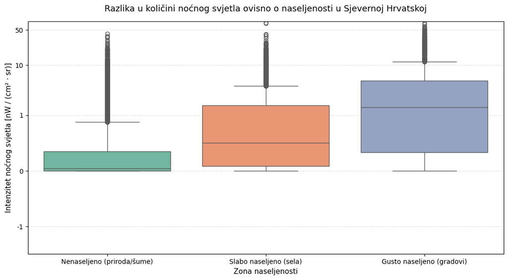

Grafikon prikazuje kako se intenzitet svjetlosnog onečišćenja drastično mijenja ovisno o stupnju naseljenosti u sjevernoj Hrvatskoj. Zbog velikih razlika između tamnih i osvijetljenih područja, korištena je prilagođena (logaritamska) skala na Y-osi kako bi se jasno uočili svi detalji.

- **Nenaseljeno (priroda/šume):** U ovoj zoni većina prostora (šume, polja, brežuljci) ima vrijednosti blizu same nule, što znači da je tu prirodna tama najbolje očuvana. Međutim, dugačak "rep" s točkicama prema gore pokazuje da se svjetlost iz obližnjih naselja prelijeva (stvara sjaj na nebu) čak i nad područjima gdje nitko ne živi.
- **Slabo naseljeno (sela):** Ovdje se cijela kutija i njezina središnja vodoravna crta (medijan) jasno podižu iznad nule. To je dokaz da u seoskim sredinama sjeverne Hrvatske, zbog lokalne ulične rasvjete i kuća, pozadinska tama nepovratno nestaje i bilježi se stalno prisutno svjetlosno onečišćenje niskog intenziteta.
- **Gusto naseljeno (gradovi):** Ova zona bilježi nagli i najveći skok. Kutija je pozicionirana visoko iznad svih ostalih, a njezina gornja granica i točke dostižu maksimalne vrijednosti na grafikonu. To dokazuje da urbana središta (poput Varaždina, Čakovca, Koprivnice i drugih) djeluju kao masivna, intenzivna žarišta koja emitiraju daleko najviše svjetla u okoliš.

Nakon vizualne analize distribucije podataka, u ovom koraku se provodi statistička i prostorna provjera dobivenih rezultata. Prvi dio obuhvaća primjenu neparametarskog Kruskal-Wallis testa kako bi se matematički dokazalo jesu li uočene razlike u intenzitetu svjetla između šuma, sela i gradova statistički značajne. Drugi dio donosi prostorni izračun u kojem se računa postotak teritorija sjeverne Hrvatske koji je još uvijek pošteđen umjetne rasvjete i nalazi se u zoni očuvane prirodne tame.

```
--- RAČUNANJE STATISTIKE I PROSTORNA ANALIZA TAME ---
```

| Statistički / Prostorni pokazatelj | Broj piksela | Vrijednost / Udio |
| --- | --- | --- |
| Zona očuvane pozadinske tame (VIIRS <= 0.1) | 17313 | 51.37% |
| Zona svjetlosnog onečišćenja (VIIRS > 0.1) | 16389 | 48.63% |
| UKUPNO ANALIZIRANI PROSTOR | 33702 | 100.00% |
| H-statistika (Kruskal-Wallis test) | - | 4583.40 |
| p-vrijednost (Značajnost razlike zona) | - | 0.0000e+00 |

Dobiveni rezultati u tablici pružaju ključne prostorne i statističke dokaze o stanju noćnog okoliša i utjecaju naseljenosti na području sjeverne Hrvatske.

#### 1. Prostorna bilanca tame i svjetlosnog onečišćenja

- **Očuvanost noćnog neba (51.37%):** Analiza pokazuje da se veći dio teritorija (**17,313 piksela**) tehnički još uvijek nalazi u zoni očuvane pozadinske tame ($VIIRS \leq 0.1$). S obzirom na naseljenu mrežu sjeverne Hrvatske, ovaj podatak naglašava kritičnu važnost nenaseljenih gorskih masiva (Ivanščica, Kalnik, dijelovi Bilogore) te prirodnih nizina uz rijeke Dravu i Muru.
- **Opseg antropogenog pritiska (48.63%):** Gotovo polovica analiziranog prostora (**16,389 piksela**) zahvaćena je mjerljivim svjetlosnim onečišćenjem ($VIIRS > 0.1$). To ukazuje na izrazito visoku razinu fragmentacije noćnog okoliša i konstantan ekološki pritisak umjetne rasvjete na floru, faunu i lokalne ekosustave na skoro 50% teritorija regije.

#### 2. Validacija razlika među zonama (Kruskal-Wallis test)

- **Ekstremno visoka H-statistika (4583.40):** Ova vrijednost potvrđuje da su razlike u intenzitetu noćnog svjetla između triju promatranih zona (nenaseljeno, sela, gradovi) masivne i prostorno izrazito strukturirane.
- **p-vrijednost (0.0000e+00):** Vrijednost p-parametra koja teži čistoj nuli dokazuje da uočeni uzorak **ima maksimalnu statističku značajnu razliku ($p < 0.05$)**. Time je matematički odbačena svaka mogućnost slučajnosti i nedvojbeno potvrđeno da stupanj antropogenog razvoja i gustoća naseljenosti izravno i zakonito upravljaju razinom degradacije noćnog neba.

## Zaključak

Najviše razine svjetlosnog onečišćenja prisutne su u administrativnim središtima, gdje su vrijednosti višestruko veće u odnosu na okolna ruralna područja. Prostorne vizualizacije dodatno potvrđuju koncentraciju svjetlosne emisije u gradskim zonama, uz postupno širenje intenzivnijih područja prema periferiji tijekom vremena.

Ukupno gledano, rezultati upućuju na sustavno povećanje svjetlosnog onečišćenja. Time se naglašava potreba za detaljnijim kvantitativnim analizama i praćenjem, kao i za razmatranjem konkretnih mjera usmjerenih na kontrolu i smanjenje umjetne rasvjete, osobito u urbanim sredinama.